# assignment 3

# 2)

# A)

```r
caffeines <- c(0, 50, 100, 150, 200)
students_n <- rep(300, 5)
a_grades <- c(109, 155, 175, 158, 103)

caff_2 <- data.frame(caffeine = caffeines,n = students_n, Agrade = a_grades)

mod.quad <- glm(cbind(Agrade,n-Agrade)~caffeine +I(caffeine^2),
                      family=binomial, data =caff_2)

summary(mod.quad)
```

```
##
## Call:
## glm(formula = cbind(Agrade, n - Agrade) ~ caffeine + I(caffeine^2),
##     family = binomial, data = caff_2)
##
## Coefficients:
##                 Estimate Std. Error z value Pr(>|z|)
## (Intercept)   -5.805e-01  1.128e-01  -5.146 2.66e-07 ***
## caffeine       1.840e-02  2.651e-03   6.940 3.93e-12 ***
## I(caffeine^2) -9.327e-05  1.272e-05  -7.331 2.28e-13 ***
## ---
## Signif. codes:  0 '***' 0.001 '**' 0.01 '*' 0.05 '.' 0.1 ' ' 1
##
## (Dispersion parameter for binomial family taken to be 1)
##
##     Null deviance: 55.54424  on 4  degrees of freedom
## Residual deviance:  0.22086  on 2  degrees of freedom
## AIC: 36.793
##
## Number of Fisher Scoring iterations: 3
```

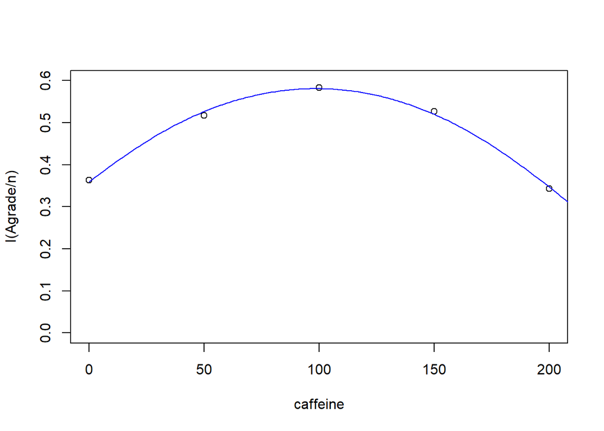

```r
p.quad=predict(mod.quad, newdata=new.df,type="response")


plot(I(Agrade/n)~caffeine, ylim=c(0,.6), data=caff_2)
caffs=seq(0, 500, by=1)
new.df=data.frame(caffeine=caffs)
p.quad=predict(mod.quad, newdata=new.df,type="response")
lines(caffs, p.quad, col="blue")
```

```r
vcov(mod.quad)
```

```
##                 (Intercept)      caffeine I(caffeine^2)
## (Intercept)    1.272482e-02 -2.226622e-04  8.287286e-07
## caffeine      -2.226622e-04  7.027689e-06 -3.232232e-08
## I(caffeine^2)  8.287286e-07 -3.232232e-08  1.618650e-10
```

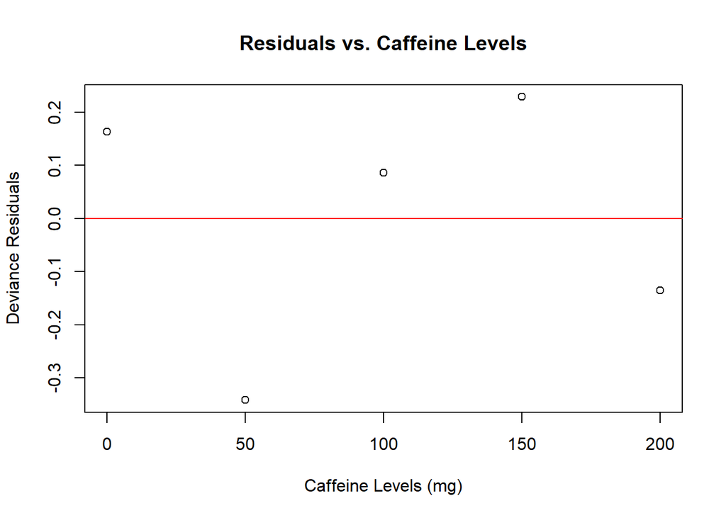

```r
# Calculate deviance residuals and plot them
residuals_dev <- residuals(mod.quad, type = "deviance")
plot(caff_2$caffeine, residuals_dev, xlab = "Caffeine Levels (mg)", ylab = "Deviance Residuals",
     main = "Residuals vs. Caffeine Levels")
abline(h = 0, col = "red", lty = 1)
```

# B)

```r
beta <- coef(mod.quad)
beta1 <- beta["caffeine"]
beta2 <- beta["I(caffeine^2)"]

x_peak <- -beta1 / (2 * beta2)
delta_g <- matrix(c(0, -1/(2*beta2), beta1/(2*beta2^2)), nrow = 3)
var_beta <- vcov(mod.quad)
var_x_peak <- t(delta_g) %*% var_beta %*% delta_g
se_x_peak <- sqrt(var_x_peak)

print(paste("Estimated x_peak:", x_peak))
```

```
## [1] "Estimated x_peak: 98.6170572087436"
```

```r
print(paste("Variance of x_peak:", var_x_peak))
```

```
## [1] "Variance of x_peak: 16.5036225318431"
```

```r
print(paste("Standard Error of x_peak:", se_x_peak))
```

```
## [1] "Standard Error of x_peak: 4.06246508069215"
```

The output above is the calculation for caffeine peak levels and its properties in terms of how and what precise levels of caffeine can enhance students performance in terms of achieving A grades. The estimate of caffeine peak is the estimated caffeine levels (Mgs) that maximise the probability of a student achieving an A grade; it is calculated by dividing beta 1 by 2 multiplied by beta 2. The standard error is the square root of the variance, and it is an indication of the caffeine peak level accuracy. The results above show that approximately 98.63 mg is the peak of caffeine levels, meaning that students have the best performance at that level. This is consistent with what was seen in the last part of the plot. The standard error suggests that the precision of the x caffeine peak is around 4.06 mg, showing high precision, and it will be close to the estimate in most cases. However, a 95% confidence interval would be a good addition for more accuracy as each student can have a different tolerance level and reaction to different caffeine levels.

# C)

```r
beta <- coef(mod.quad)
beta1 <- beta["caffeine"]
beta2 <- beta["I(caffeine^2)"]

Delta.g <- c(0, -1/(2 * beta2), beta1 / (2 * beta2^2))

print(Delta.g)
```

```
##               I(caffeine^2)      caffeine
##         0.000      5360.597   1057292.592
```

# D)

```r
var_peak <- t(Delta.g) %*% vcov(mod.quad) %*% Delta.g

print(var_peak)
```

```
##          [,1]
## [1,] 16.50362
```

The output above is the calculated variance of x peak of caffeine. This is estimated by using the delta method, an approach that will allow us to estimate the variance function of multiple variables. 16.5 is simply the measure of how far the values are from the mean of 98.6. This also shows us the uncertainty and the accuracy of the model as it shows us how spread the values can be.

# E)

```r
ci_lower <- x_peak - 1.96 * se_x_peak
ci_upper <- x_peak + 1.96 * se_x_peak

print(paste(ci_lower, ci_upper))
```

```
## [1] "90.654625650587 106.5794887669"
```

The output above provides us with the 95% confidence interval as the question asked us to. The confidence interval suggests that 95% of our values should fall between 90.65 and 106.57 mgs of caffeine for the optimal result of a A grade score, this includes our x peak caffeine level of 98.6 that falls right in our 95% confidence interval. Our confidence interval will also measures levels of uncertainty as unusually when the confidence interval values are too far apart it may mean that the model is not precise which is not the case in here.

# 3)

# A)

```r
ns <- caff_2$n
xs <- caff_2$caffeine

preds <- predict(mod.quad, type = "response")

ys <- rbinom(length(ns), size = ns, prob = preds)

print(ys)
```

```
## [1] 102 156 184 174  95
```

The output above shows the simulated counts of students achieving A grades under the influence of caffeine at different levels. The counts are achieved using a GLM, specifically a quadratic model and a nonlinear relationship, as the counts are different depending on the level. The numbers above represent the simulated counts of grades using a binomial distribution. There is also a normal distribution as there is a gradual increase and decrease in the values, possibly due to the nature of the model and the use of binomial or logistic regression.

# B)

```r
library(MASS)


x <- seq(from = min(xs), to = max(xs), length.out = length(xs))
n <- rep(100, length(x))
b0 <- -5.805e-01
b1 <- 1.840e-02
b2 <- -9.327e-05
probs <- plogis(b0 + b1 * x + b2 * x^2)

n.sims <- 1000
xpeaks <- numeric(n.sims)
devs <- numeric(n.sims)

for (i in 1:n.sims) {
    ys <- rbinom(length(x), size = n, prob = probs)

    fit <- glm(cbind(ys, n - ys) ~ x + I(x^2), family = binomial)

    coef_fit <- coef(fit)
    x_peak <- -coef_fit[2] / (2 * coef_fit[3])
    xpeaks[i] <- x_peak

    devs[i] <- deviance(fit)
}

print(summary(xpeaks))
```

```
##    Min. 1st Qu.  Median    Mean 3rd Qu.    Max.
##   68.66   94.22   98.76   98.81  103.64  126.77
```

```r
print(summary(devs))
```

```
##     Min.  1st Qu.   Median     Mean  3rd Qu.     Max.
##  0.00119  0.55086  1.35034  2.00006  2.80354 16.45639
```

# C)

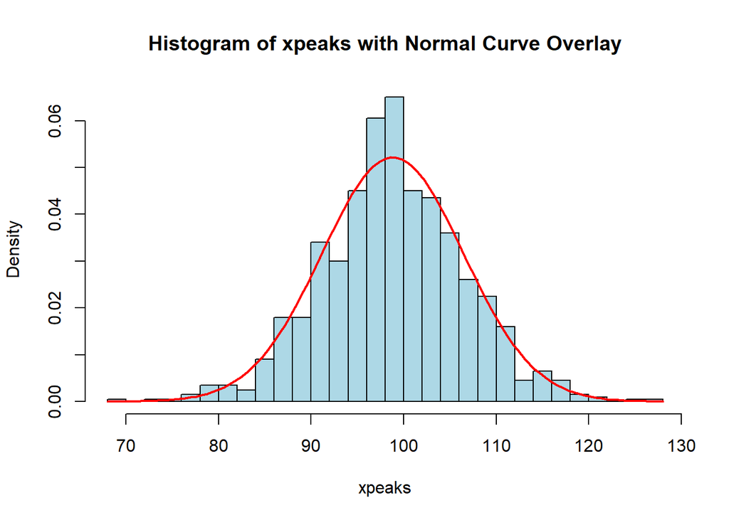

```r
hist(xpeaks, breaks = 30, freq = FALSE, main = "Histogram of xpeaks with Normal Curve Overlay", xlab = "xpeaks", col = "light blue")

curve(dnorm(x, mean = mean(xpeaks, na.rm = TRUE), sd = sd(xpeaks, na.rm = TRUE)), add = TRUE, col = "red", lwd = 2)
```

```r
quantiles_xpeaks <- quantile(xpeaks, probs = c(0.025, 0.975), na.rm = TRUE)
print(quantiles_xpeaks)
```

```
##      2.5%     97.5%
##  84.05159 114.72809
```

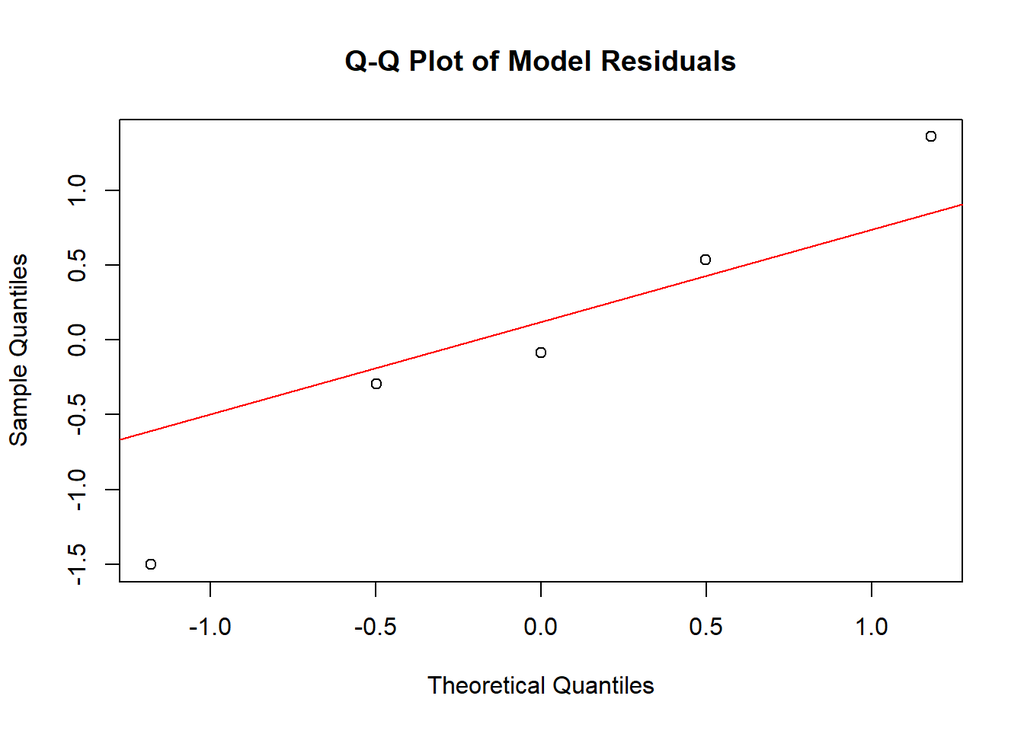

```r
qqnorm(residuals(fit, type = "deviance"), main = "Q-Q Plot of Model Residuals")
qqline(residuals(fit, type = "deviance"), col = "red")
```

# D)

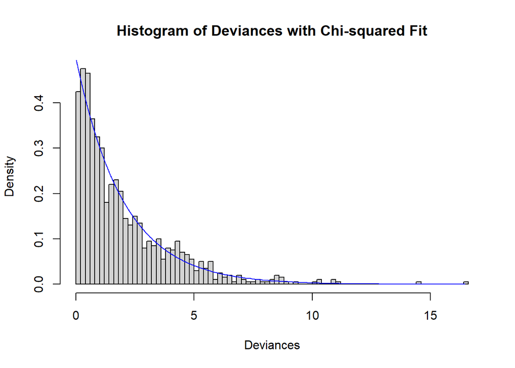

```r
hist(devs, breaks = 100, prob = TRUE, main = "Histogram of Deviances with Chi-squared Fit", xlab = "Deviances")

n <- length(ns)
p <- 3
df <- n - p

dvs <- sort(devs)
lines(dvs, dchisq(dvs, df), col = "blue")
```

The histogram above shows the chi-square distribution and it indicates a good fit aligned with observations distributions and deviance. The deviance are more scattered and centered around lower values and they decline rapidly, the data however may not meet the assumptions underlying the chi square test of deviance including independence of observations and the high volume of low deviance values suggests that the model sits close to the observed data which may be caused by over fitting and the long tail of the model suggests that the there may be some overdispertion presented in the outlines affecting the higher deviance values.